# ISA 401: Business Intelligence & Data Visualization

## 22: Charts for High-Dimensional Data

### Fall 2026

# Before We Start

1 Join today's Zoom, and get your phone out

Use the Zoom link in the [**Week 0 Module**](https://miamioh.instructure.com/courses/258169/modules/981092) on Canvas. **Mute** your mic and **turn off** your video.  
We start with a phone game on last class's charts. There is no R to write today: have Power BI open to follow the demos.

2 Today's plan

**Part 1.** **Race Call**: time, space, and space-time charts, on your phone. Then two check-ins that evaluate an AI-like reading of a chart, and the Exam 02 review.  
**Part 2.** What makes data high-dimensional?  
**Part 3.** Charts for it: small multiples and radar charts built in Power BI, and how to read parallel coordinates.  
**Part 4.** Other charts: heat maps, treemaps, and Chernoff faces.

# Race Call

How to play

**1.** Scan your section's code, then enter your first name, last initial and seat.

**2.** You are an analyst on the election-night chart desk. There are 13 races, and each one is a chart from the last two classes: a line, a calendar, an animation, or a map.

**3.** Make your projection on your phone before the polls close. Faster right projections earn more points.

**4.** The projector shows what the room projected, then the actual winner and why.

Points count for nothing. Nothing counts toward your grade.

Join

Section A (8:30 AM)

[figure not shown]

isa401-race-call.vercel.app/?section=A

Section B (10:05 AM)

[figure not shown]

isa401-race-call.vercel.app/?section=B

# Check-In: An Evaluation of an AI-Like Output

<countdown-timer class="countdown" id="timer_f47d75b7" minutes="2" seconds="0" update-every="1" tabindex="0" style="top:0;right:0;--countdown-font-size:2em;"></countdown-timer>

.panel[Task

[figure not shown]

Suppose an AI assistant summarized it like this"East orders are steady. Midwest orders became far more volatile after June, with sharp spikes every week. The weekend promotions there seem to be working, but demand in the Midwest has become unstable."
<b>Task.</b> In 2 minutes: the summary describes the chart. What did it miss about the <b>data itself</b>?

.panel[Your Answer

- What the AI missed: ________________

- What you would check before sharing this chart: ________________

.panel[Answer

<details class="answer-gate">
<summary>Show the answer</summary>

What the AI missed: the zerosFrom July, the Midwest shows 0 orders six days a week and a whole week's worth every Sunday. The stores did not stop selling on Mondays.
A likely causeThe Midwest started uploading its orders once a week, so each Sunday row holds seven days. Weekly totals did not change: about 2,230 orders a week before July and 2,220 after.
Why it matters"Volatile demand" and "promotions are working" are both wrong. Compare weekly totals instead of daily values. <b>Seen it before:</b> Ohio's COVID line turned into the same comb in March 2022, when the state began reporting once a week.

</details>

.panel[Two Questions to Ask

1 Does the pattern follow the business, or the reporting schedule?

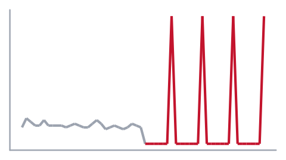

Zeros on most days and a spike on one day mean the data **arrive** once a week, not that the business changed.

Seen in: Ohio's COVID cases (Class 21) and today's Midwest orders.

2 What is one row, and could it be counted twice?

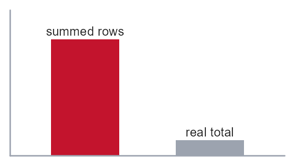

If each row is a running total, or repeats a value like population, adding up the rows counts the same thing again and again.

Seen in: Press Time (running totals and a repeated population) and the Cincinnati crashes (one row per person, not per crash).

**An AI describes the chart it is given.** Your job is to ask whether the data could be wrong. When a pattern looks too sudden, too regular, or too big, ask how the data were collected before you trust the story.

# Check-In: Another Evaluation

<countdown-timer class="countdown" id="timer_95b7a17c" minutes="1" seconds="0" update-every="1" tabindex="0" style="top:0;right:0;--countdown-font-size:2em;"></countdown-timer>

.panel[Task

[figure not shown]

<b>Task.</b> In 1 minute, from the chart: did Ohio's household income grow <b>faster before 2020 or after 2020</b>?
Source: U.S. Census Bureau, via <a href="https://fred.stlouisfed.org/series/MEHOINUSOHA672N" target="_blank">FRED (MEHOINUSOHA672N)</a>. Real data.

.panel[Your Answer

- Faster before 2020 or after 2020: ________________

- How you can tell: ________________

.panel[Answer

<details class="answer-gate">
<summary>Show the answer</summary>

[figure not shown]

After 2020, per yearThe years are 4, 4, 2 and 3 apart, but the task chart drew every step the same width. 2012 to 2020: about <b>$1,770 a year</b> (8 years). 2020 to 2025: about <b>$2,190 a year</b> (5 years).
ChatGPT got this one rightAsked the same question (Nov 5, 2026), it divided by the real gaps: "Income grew faster after 2020, increasing approximately $2,188 annually, compared with $1,768 annually from 2012 to 2020."


<b class="r">Read the axis labels, not just the slopes.</b> When years are skipped but drawn the same distance apart, every slope is bent. Put time on a real time axis, or say clearly that the gaps differ.
</details>

# Exam 02 Review

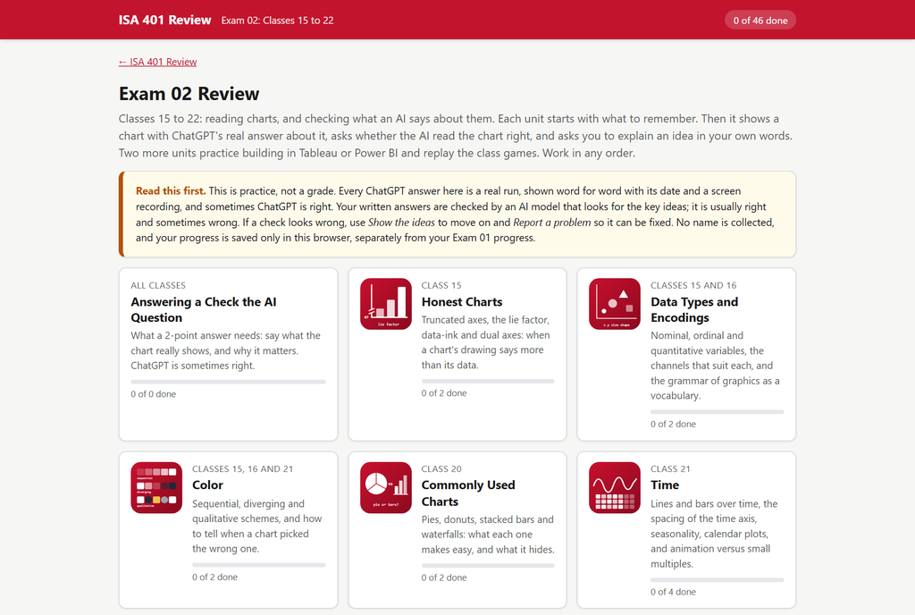

Practice for Exam 02

**Open:** [**isa401-review.vercel.app/#/exam02**](https://isa401-review.vercel.app/#/exam02)

Ungraded and no sign-in. Your progress is saved in your browser.

Start with **Answering a Check the AI Question**.

Each unit opens with a short narrated recap, then questions like today's check-ins: a chart, an AI's answer about it, and your judgment.

**Exam 02 structure and details:** see the [**Canvas announcement**](https://miamioh.instructure.com/courses/258169/discussion_topics/2356587).

# Learning Objectives

By the end of today, you should be able to:

1. **Describe** what high-dimensional data is.

2. **Give examples** of charts used for high-dimensional data.

3. **Construct** these charts in Power BI.

# Part 2: High-Dimensional Data

# What Is High-Dimensional Data?

<countdown-timer class="countdown" id="timer_b0d686c2" minutes="3" seconds="0" update-every="1" tabindex="0" style="top:0;right:0;--countdown-font-size:2em;"></countdown-timer>

.panel[Activity

> In 3 minutes, define the terms in the next tab in the context of this table.

| Order ID | Order Date | Order Priority | Product Container | Product Cost | Ship Date |
| --- | --- | --- | --- | --- | --- |
| 1 | 1/1/2022 | 5 - low | Large box | 25 | 1/5/2022 |
| 2 | 1/4/2022 | 4 - not specified | Small Box | 36 | 1/7/2022 |
| 3 | 1/15/2022 | 2- high | Small Box | 38 | 1/17/2022 |
| 3 | 1/15/2022 | 2- high | Small Box | 41 | 1/17/2022 |
| 3 | 1/15/2022 | 2- high | Jumbo Box | 44 | 1/17/2022 |
| 3 | 1/15/2022 | 2- high | Wrap Bag | 33 | 1/17/2022 |
| 4 | 1/18/2022 | 1- urgent | Small Box | 33 | 1/19/2022 |
| 5 | 1/20/2022 | 3- medium | Medium Box | 40 | 1/23/2022 |
| 5 | 1/20/2022 | 3- medium | Small Box | 16 | 1/23/2022 |
| 5 | 1/20/2022 | 3- medium | Large box | 38 | 1/23/2022 |

[output cut: 1 more lines]

.panel[Your Solution

**Data Types:** (Edit below)

- Multivariate data: ________________

- Big Data: ________________

- Tall Data: ________________

- Wide Data: ________________

- High Dimensional Data: ________________

# Taxonomy

**Based on the number of attributes:**

- 1: Univariate
- 2: Bivariate
- 3: Trivariate
- 4+: Multivariate

**Things to Think about:**

- What is the problem with visualizing multivariate (especially when there are more than 6 to 7 dimensions) data? ______________

- Any ideas about what to do? ______________

# Recall: Six Variables in One Chart

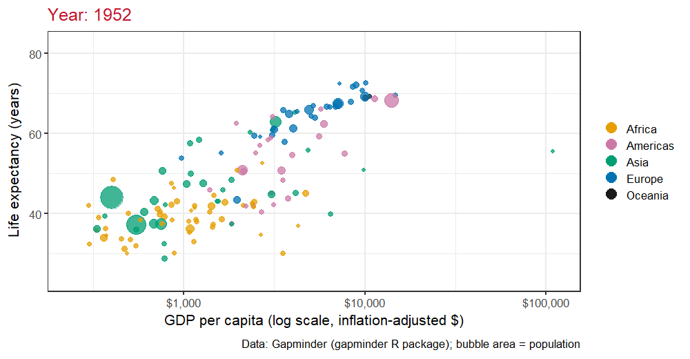

One answer: more channels

**each bubble:** a country

**x:** GDP per capita

**y:** life expectancy

**area:** population

**color:** continent

**motion:** year

**That is about the limit.** A seventh variable has no channel left that the eye can read. The rest of today's charts find other ways to show many variables at once.

# Part 3: Examples of High-Dimensional Charts

## Built in Power BI

# Small Multiples

> Illustrations of postage-stamp size are indexed by category or a label, sequenced over time like the frames of a movie, or ordered by a quantitative variable not used in the single image itself -- [Tufte, E.R.: Envisioning Information, Graphics Press, 1990](https://www.amazon.com/exec/obidos/tg/detail/-/0961392118/)

[figure not shown]

# Small Multiples in Power BI

Let us use Power BI to create a similar chart to the one below. We will be using the [mpg_2023_large.csv](https://raw.githubusercontent.com/fmegahed/isa401/main/data/mpg_2023_large.csv).

[figure not shown]

How to read it
One small chart <b>per measure</b>, each split by manufacturer.
Each panel keeps <b>its own scale</b>: CO2 is in the hundreds, cylinders are 4 to 8.
Compare <b>across</b> panels: the brands with the most CO2 also have the lowest MPG.
Power BI has no built-in box plot, so we will show each manufacturer's average instead.

# Parallel Coordinates

[figure not shown]

# Radar Charts

> Charts show how individual things perform across multiple measures

[figure not shown]

# Radar Charts in Power BI

Let us add the [Radar Chart App](https://appsource.microsoft.com/en-us/marketplace/apps?product=power-bi-visuals&page=1&src=office&search=radar) to our Power BI and use it to visualize the [mpg_2023_sample.csv](https://raw.githubusercontent.com/fmegahed/isa401/main/data/mpg_2023_sample.csv).

[figure not shown]

How to read it
One <b>spoke</b> per measure, rescaled from 0 to 1; one <b>polygon</b> per car.
Bigger is not always better: a long <b>CO2</b> spoke is bad, a long <b>MPG</b> spoke is good.
Past 3 or 4 polygons, the shapes pile up. Then use <b>small multiples</b>: one radar per car.

# Part 4: Other Charts

# Other Charts: Heat Map

- each column is a variable

- each obs is a row

- each square is a value; closer to yellow the higher

[figure not shown]

# Other Charts: TreeMaps

> Treemaps simultaneously show the big picture, comparisons of related items, and allow easy navigation to the details. [Juice Analytics](https://www.juiceanalytics.com/writing/10-lessons-treemap-design)

**Encoding mechanisms:**

Each box in a treemap can show two measures:
- area of the boxes should be a **quantity measure**. The measures should sum up along the hierarchical structure of the data. The sum of all the elements in one branch need to sum to the value of the branch as a whole.
- Color of the boxes is best suited to a **measure of performance or change** such as growth over time, average conversion rate, or customer satisfaction.

# Other Charts: TreeMaps

> Treemaps simultaneously show the big picture, comparisons of related items, and allow easy navigation to the details. [Juice Analytics](https://www.juiceanalytics.com/writing/10-lessons-treemap-design)

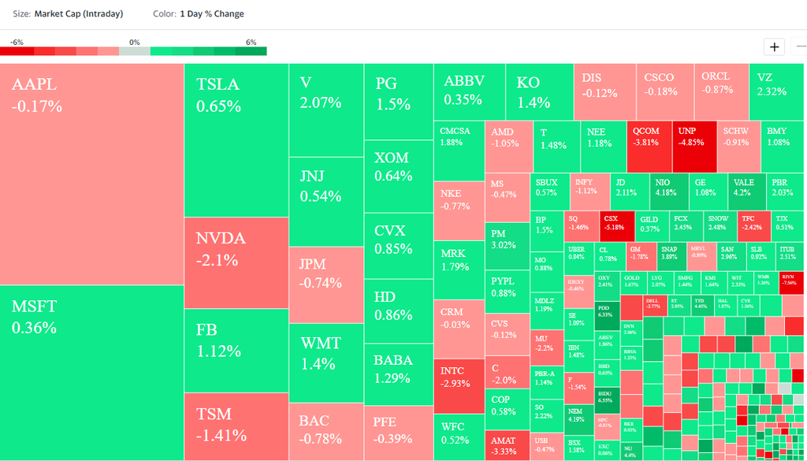

# Other Charts: Chernoff Faces

.center[

[figure not shown]

]

# Recap

# Summary of Main Points

- Describe what is high-dimensional data: many variables per observation, more than x, y and color can carry

- Provide some examples for graphs used for high-dimensional datasets: small multiples, parallel coordinates, radar charts, heat maps, treemaps, and Chernoff faces

- Construct these graphs using software: Power BI's own visuals, or one added from AppSource

# Before Next Class

**Wednesday, Nov 11:** Business Reporting. **Monday, Nov 16:** Exam 02, Data Visualization & Communication.

Suggested

Wilke, *Fundamentals of Data Visualization*: [**ch. 12, Visualizing associations among two or more quantitative variables**](https://clauswilke.com/dataviz/visualizing-associations.html).

Free online. Bubble charts, correlograms, and what to do with many variables.

Wilke: [**ch. 21, Multi-panel figures**](https://clauswilke.com/dataviz/multi-panel-figures.html).

Small multiples, and when panels should share an axis.

Skim if curious

Microsoft Learn: [**Small multiples in Power BI**](https://learn.microsoft.com/en-us/power-bi/visuals/power-bi-visualization-small-multiples).

Which visuals support them, and the layout options.

Juice Analytics: [**10 lessons in treemap design**](https://www.juiceanalytics.com/writing/10-lessons-treemap-design).

What area and color should each encode.